# BLAM_Liege_beh_analyses

Jacek Matuszewski

2023-09-08

#BLAM 7T Behavioural analyses: Localizers

## List of tasks:

### Auditory Motion Localizer

Stimuli:

Experimental design:

Conditions & Task(s)

- *Motion* (**Press the button for repetition of sound direction**)
- *Static* (**Press the button for repeated double short bursts**)

Subject exclusions sub-SC05 (data not acquired) sub-EB02 (no responses)

### Visual Motion Localizer

Stimuli:

Experimental design:

Conditions & Task(s)

- *Motion* (**Press the button for repetition of sound direction**)
- *Static* (**Press the button for repeated double short bursts**)

Subject exclusions: sub-SC05 (data not acquired)

### MT/MST Localizer

Stimuli:

Experimental design:

Conditions & Task(s)

- *Motion* (**Press the button for shorter event**)

Subject exclusions: sub-SC05 (data not acquired)

## Analytical approach:

Given no 1-to-1 matching between target events and responses the approach here was to use the *time window* for correct answers, i.e., monitoring whether the response occurred within *3 seconds* of the target.

Plots include individual values and group mean +- standard error.

Group / conditions / axis of motion differences are tested with ANOVAs.

## Auditory motion loc behavioural accuracy

Descriptive stats: group level [% correct]

[output not shown]

Plot (flagging outliers)

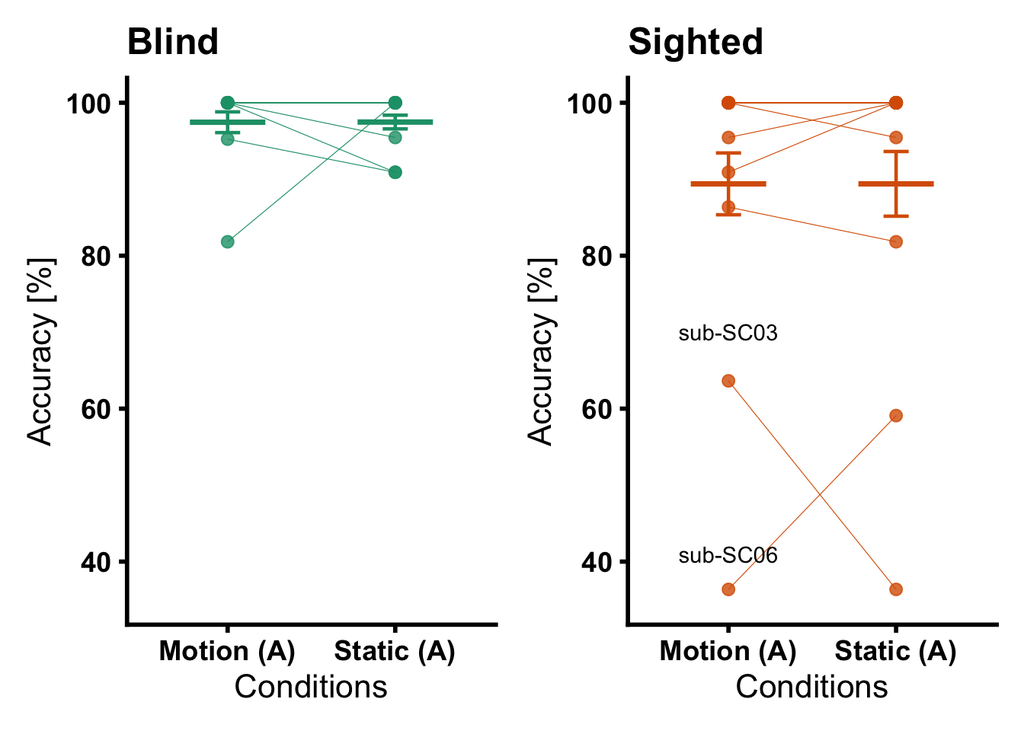

ANOVA 2 (group: blind + sighted) x 2 (condition: motion + static)

```
## $ANOVA
##       Effect DFn DFd          F         p p<.05          ges
## 2      group   1  21 0.09693821 0.7586051       4.472246e-03
## 3       cond   1  21 0.03558505 0.8521861       4.543195e-05
## 4 group:cond   1  21 0.02431571 0.8775736       3.104466e-05
```

While there are 2 sighted outliers with worse performance, there are no differences between blind and sighted and between motion and static conditions.

## Visual Motion localizers (regular + MT/MST)

Descriptive stats: group level [% correct]

```
## # A tibble: 3 × 4
## # Groups:   task [2]
##   task            cond   mean_accu sd_accu
##   <chr>           <chr>      <dbl>   <dbl>
## 1 mtMstLocalizer  motion      94.6   18.0
## 2 visualLocalizer motion      98.5    3.99
## 3 visualLocalizer static      96.4   11.1
```

Plot (flagging outliers)

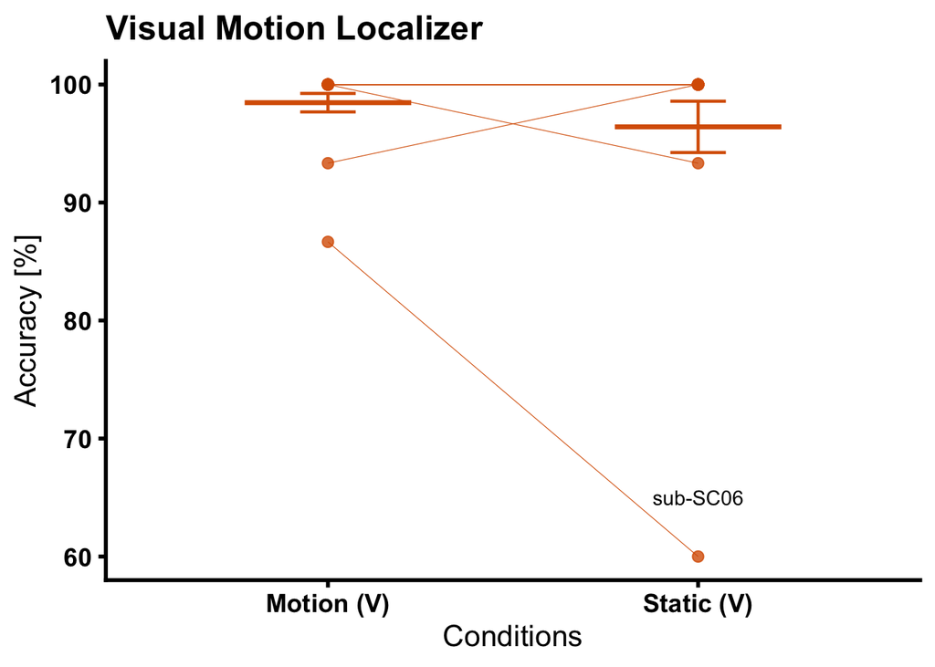

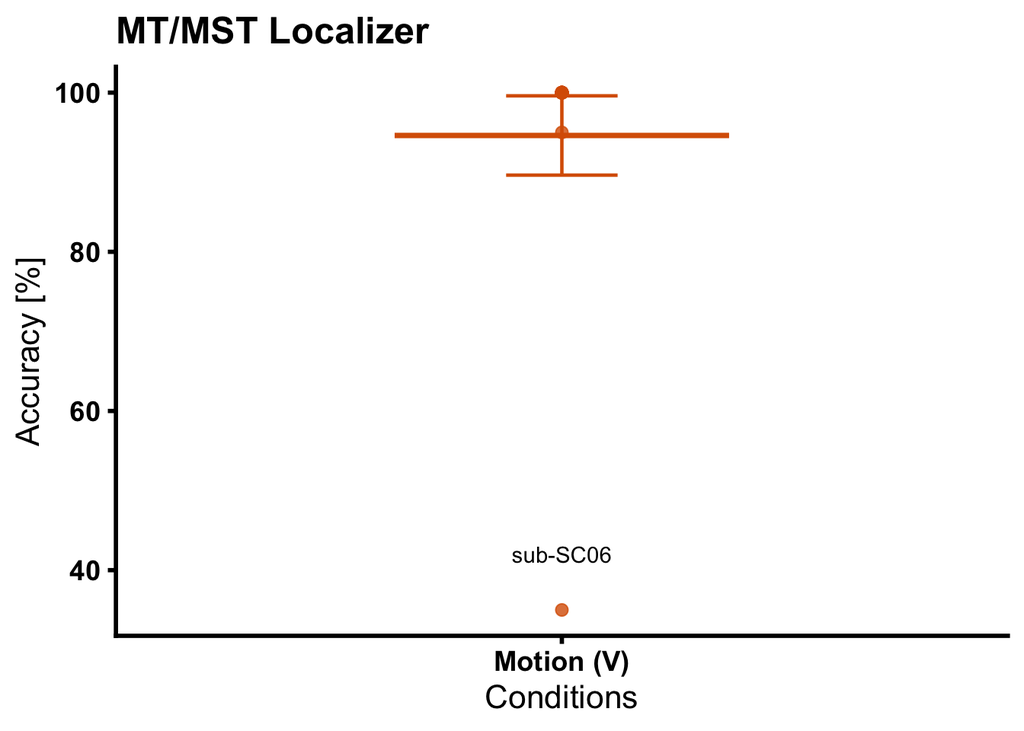

ANOVA (Vis motion only, since there is no static condition in MT/MST localizer. Equvalent of a T test)

```
## $ANOVA
##   Effect DFn DFd         F         p p<.05        ges
## 2   cond   1  12 0.8807339 0.3665067       0.01612903
```

sub SC-06 is performing worse, but there are no differences between conditions.